# Calculate & Explore ssGSEA & GSVA Enrichment scores for Davids signatures

Lewis E Tomalin

2025-03-26

requires data:

‘data/processed/DGE_final_samples.rda’ ‘data/raw/gene_signatures_with_APMs_IFNG.Symbol.txt’

creates data:

‘data/processed/db_ssGSEA_David_correct.rda’ ‘data/processed/db_GSVA_David_correct.rda’

## Summary

This script does the following

- Calculates and saves enrichment scores (ssGSEA & GSVA) for Davids immune-cell signatures
- This includes re-calculation of IIL and TIL (immune_infiltration_David, tcell_infiltration_David)
- Performs statistical analysis and makes plots

The enrichment calculations are performed on log cpm + 1.

No genes were filtered out prior to enrichment score calculations.

The stars represent adjusted p-values. (adjustment is performed within each signature using Benjamini-Hochberg).

It has not been adjusted across gene-sets (ie we are not treating this as a screen)

NOTE: You need to run the first chunk before knitting (you only need to do this once)

### Sanity check

The numbers in the tables below should be consistent across all reports.

If there are differences, this will indicate that ‘data/processed/DGE_final_samples.rda’ is not up to date.

```
##
##                                   Overall
##   n                                  36
##   age (mean (SD))                 58.74 (15.51)
##   sex = Male (%)                     23 (63.9)
##   prog_type = with_MIS (%)            4 (11.1)
##   csd = High_CSD (%)                  4 (11.1)
##   solar_elastosis_score (%)
##      1                                3 ( 8.3)
##      1+                              12 (33.3)
##      2-                               7 (19.4)
##      2                                9 (25.0)
##      2+                               2 ( 5.6)
##      3-                               1 ( 2.8)
##      3                                1 ( 2.8)
##      3+                               1 ( 2.8)
##   age_centered (mean (SD))         0.47 (15.51)
##   age_centered_impute (mean (SD))  0.46 (15.29)
```

```
##
##                                  Overall
##   n                              97
##   final_tissue_type_category (%)
##      Nevus                       28 (28.9)
##      Intermediate                 5 ( 5.2)
##      MIS                          4 ( 4.1)
##      RGP                         22 (22.7)
##      VGP                         38 (39.2)
```

### Plot results, David signatures ssGSEA, log2 cpm CORRECT

The plots below were calculated by Lewis based on Davids signatures

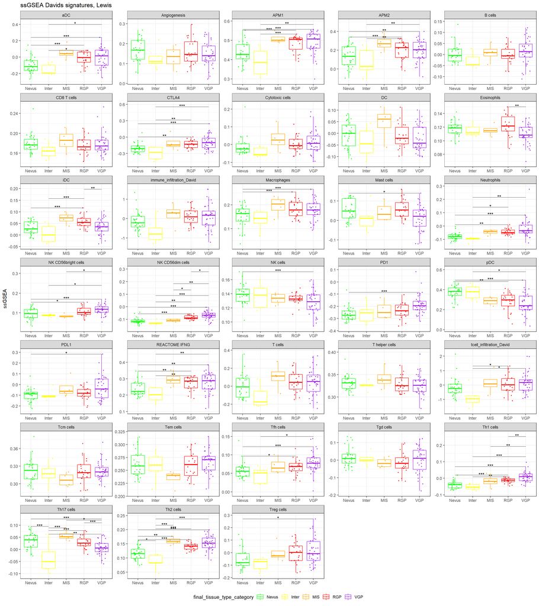

### Plot results, David signatures GSVA, log2 cpm CORRECT

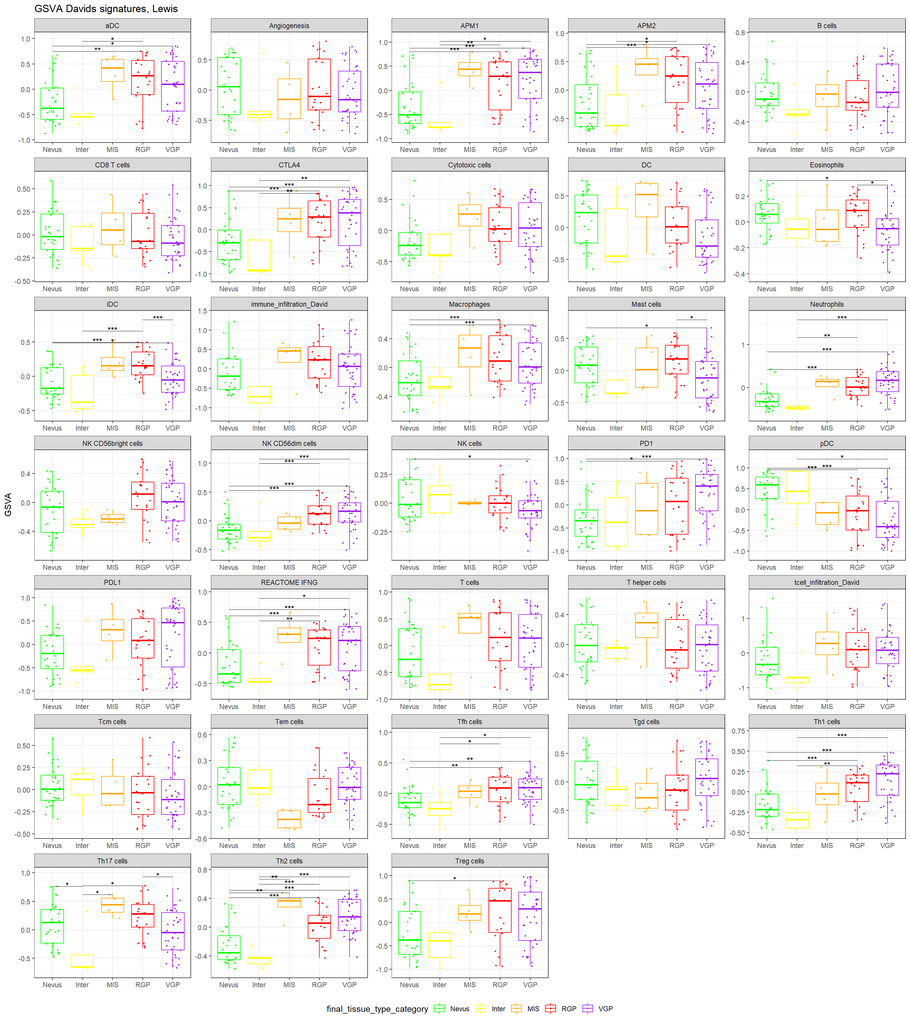

### Why are some gene-sets inconsistent between ssGSEA and GSVA?

Let’s take a look at Th17 cells signature.

Notice there are more differences in the ssGSEA analysis.

ssGSEA: Is rank based, thus, scores can be inflated by one or two very high expression genes.

GSVA: Is distribution based, and is less impacted by individual genes.

Perhaps 1 or 2 extreme genes in the Th17 signature and leading to the increased differences in ssGSEA scores.

The visualizations below can be modified using *gs_of_interest*

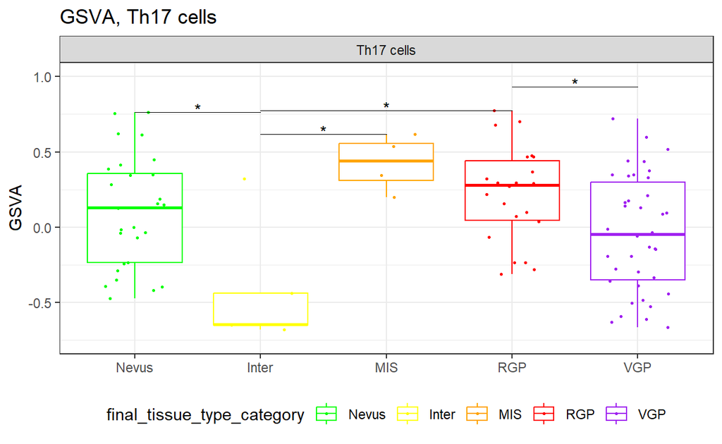

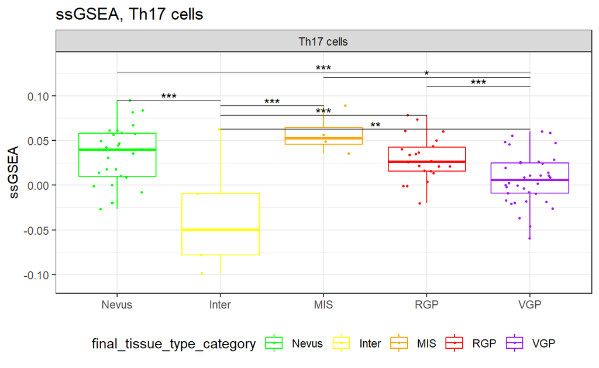

#### Heatmaps visualizing Th17 genes

Ordered by GSVA score.

Scaled by column.

Notice, only three genes in the set

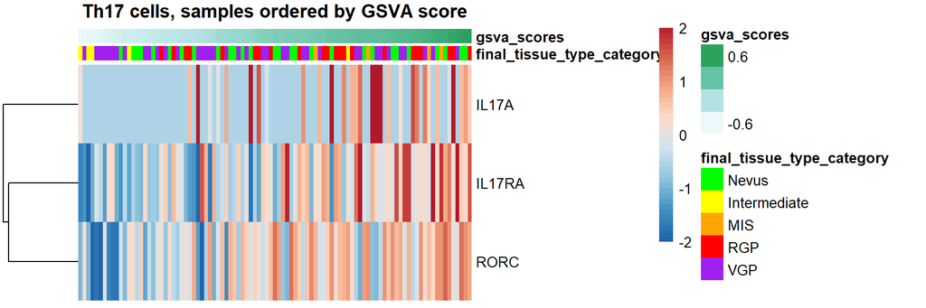

Ordered by ssGSEA score.

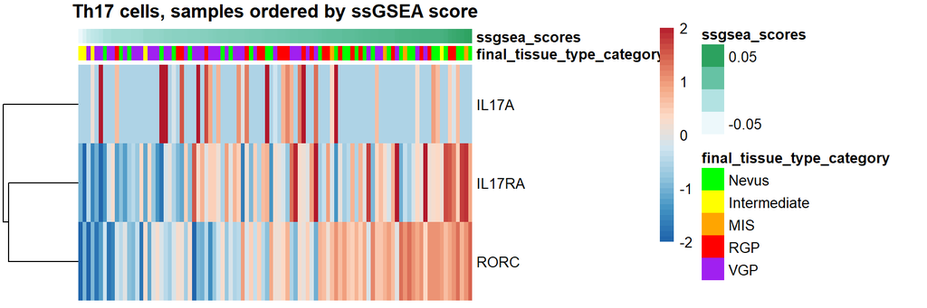

### STOP, CODE BELOW IS NOT USED